```
                Kaggle Competition : Team 1 (DIA2)
```

Members : Yassine CHENIK Emine BOUCHIBA

1. Data Preprocessing :

Installing the libraries we will use :

```r
#install.packages("caTools")
#install.packages("rpart")
#install.packages("MASS")
#install.packages("caret")
#install.packages("rpart.plot")
#install.packages("randomForest")
#install.packages("gbm")
#install.packages("e1071")
#install.packages("xgboost")
#install.packages("caretEnsemble")
```

Importing the libraries we will use :

```r
library("caTools")
library("rpart")
library("MASS")
library("caret")
```

```r
library("rpart.plot")
library("randomForest")
library("gbm")
library("e1071")
library("xgboost")
library("caretEnsemble")
```

Importing the training set and the test set :

```r
train = read.csv(file = "C:/Users/yassi/OneDrive - De Vinci/ESILV/A4/Semestre 07/Machine Learning/Kaggle competition/train.csv.")
test = read.csv(file = "C:/Users/yassi/OneDrive - De Vinci/ESILV/A4/Semestre 07/Machine Learning/Kaggle competition/test.csv")

head(train)
```

```
##   age sex   bmi children smoker region   charges
## 1  46   F 19.95        2      N     NW  9193.838
## 2  47   F 24.32        0      N     NE  8534.672
## 3  52   F 24.86        0      N     SE 27117.994
## 4  39   F 34.32        5      N     SE  8596.828
## 5  54   F 21.47        3      N     NW 12475.351
## 6  63   M 41.47        0      N     SE 13405.390
```

```r
head(test)
```

```
##   age sex    bmi children smoker region
## 1  45   F 25.175        2      N     NE
## 2  36   F 30.020        0      N     NW
## 3  64   F 26.885        0      Y     NW
## 4  46   M 25.745        3      N     NW
## 5  19   M 31.920        0      Y     NW
## 6  34   M 42.900        1      N     SW
```

Changing values to numeric ones :

```r
###For train :

#Encoding values :
train$region=factor(train$region,levels=c('NE','NW','SE','SW'),labels=c(0.0,1.0,2.0,3.0))
train$sex=factor(train$sex,levels=c('M','F'),labels=c(0,1))
train$smoker=factor(train$smoker,levels=c('N','Y'),labels=c(0.0,1.0))

#Converting to numeric values :
train$sex=as.numeric(as.character(train$sex))
train$smoker=as.numeric(as.character(train$smoker))
train$region=as.numeric(train$region)
train$bmi=as.numeric(train$bmi)
train$children=as.numeric(train$children)
train$age=as.numeric(train$age)

###For test set :

#Encoding values :
test$region=factor(test$region,levels=c('NE','NW','SE','SW'),labels=c(0.0,1.0,2.0,3.0))
test$sex=factor(test$sex,levels=c('M','F'),labels=c(0.0,1.0))
test$smoker=factor(test$smoker,levels=c('N','Y'),labels=c(0.0,1.0))

#Converting to numeric values :
test$sex=as.numeric(as.character(test$sex))
test$smoker=as.numeric(as.character(test$smoker))
test$region=as.numeric(test$region)
test$bmi=as.numeric(test$bmi)
test$children=as.numeric(test$children)
test$age=as.numeric(test$age)

head(train)
```

```
##   age sex   bmi children smoker region   charges
## 1  46   1 19.95        2      0      2  9193.838
## 2  47   1 24.32        0      0      1  8534.672
## 3  52   1 24.86        0      0      3 27117.994
## 4  39   1 34.32        5      0      3  8596.828
## 5  54   1 21.47        3      0      2 12475.351
## 6  63   0 41.47        0      0      3 13405.390
```

```r
head(test)
```

```
##   age sex    bmi children smoker region
## 1  45   1 25.175        2      0      1
## 2  36   1 30.020        0      0      2
## 3  64   1 26.885        0      1      2
## 4  46   0 25.745        3      0      2
## 5  19   0 31.920        0      1      2
## 6  34   0 42.900        1      0      4
```

2. Machine Learning Models :
1. Regression Tree :
1. Fit the tree :

```r
tree=rpart(train$charges~.,data=train)
```

2. Plot of the tree :

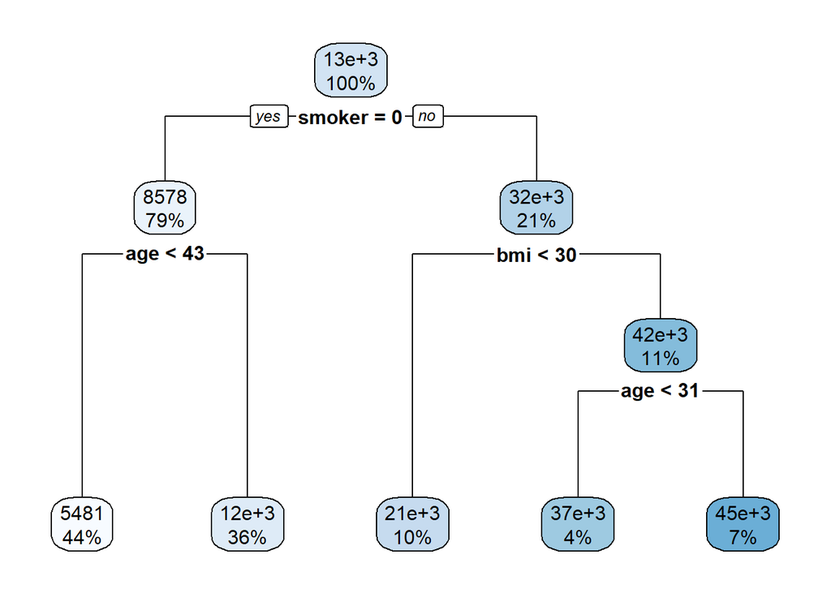

```r
rpart.plot(tree)
```

3. Summary of the tree :

```r
summary(tree)
```

```
## Call:
## rpart(formula = train$charges ~ ., data = train)
##   n= 1070
##
##           CP nsplit rel error    xerror       xstd
## 1 0.60849752      0 1.0000000 1.0013393 0.05815217
## 2 0.15059688      1 0.3915025 0.3930755 0.02149291
## 3 0.06437189      2 0.2409056 0.2433055 0.01635578
## 4 0.01067870      3 0.1765337 0.1827311 0.01496085
## 5 0.01000000      4 0.1658550 0.1776754 0.01488648
##
## Variable importance
##   smoker      bmi      age   region      sex children
##       68       17        9        4        2        1
##
## Node number 1: 1070 observations,    complexity param=0.6084975
##   mean=13346.09, MSE=1.443336e+08
##   left son=2 (850 obs) right son=3 (220 obs)
##   Primary splits:
##       smoker   < 0.5     to the left,  improve=0.608497500, (0 missing)
##       age      < 42.5    to the left,  improve=0.069661070, (0 missing)
##       bmi      < 30.17   to the left,  improve=0.045615260, (0 missing)
##       children < 1.5     to the left,  improve=0.009309770, (0 missing)
##       sex      < 0.5     to the right, improve=0.003226518, (0 missing)
##
## Node number 2: 850 observations,    complexity param=0.06437189
##   mean=8578.323, MSE=3.62466e+07
##   left son=4 (467 obs) right son=5 (383 obs)
##   Primary splits:
##       age      < 42.5    to the left,  improve=0.322672000, (0 missing)
##       children < 1.5     to the left,  improve=0.016111910, (0 missing)
##       bmi      < 20.955  to the left,  improve=0.015252670, (0 missing)
##       region   < 2.5     to the right, improve=0.004219904, (0 missing)
##       sex      < 0.5     to the left,  improve=0.003499742, (0 missing)
##   Surrogate splits:
##       bmi < 35.6625 to the left,  agree=0.571, adj=0.047, (0 split)
##
## Node number 3: 220 observations,    complexity param=0.1505969
##   mean=31767.01, MSE=1.347857e+08
##   left son=6 (105 obs) right son=7 (115 obs)
```

[output cut: 24 more lines]

```
##   Primary splits:
##       age      < 30.5    to the left,  improve=0.42445670, (0 missing)
##       bmi      < 36.245  to the left,  improve=0.07842082, (0 missing)
##       children < 0.5     to the left,  improve=0.05806770, (0 missing)
##       region   < 3.5     to the right, improve=0.01939809, (0 missing)
##       sex      < 0.5     to the left,  improve=0.00213826, (0 missing)
##   Surrogate splits:
##       children < 0.5     to the left,  agree=0.652, adj=0.070, (0 split)
##       bmi      < 30.205  to the left,  agree=0.635, adj=0.023, (0 split)
##
## Node number 14: 43 observations
##   mean=36691.43, MSE=9769187
##
## Node number 15: 72 observations
##   mean=44518.22, MSE=2.522422e+07
```

Let’s get the cross validation results by using the Complexity Parameters (CP). Here, we will use the printpc() function of r :

```r
printcp(tree)
```

```
##
## Regression tree:
## rpart(formula = train$charges ~ ., data = train)
##
## Variables actually used in tree construction:
## [1] age    bmi    smoker
##
## Root node error: 1.5444e+11/1070 = 144333622
##
## n= 1070
##
##         CP nsplit rel error  xerror     xstd
## 1 0.608498      0   1.00000 1.00134 0.058152
## 2 0.150597      1   0.39150 0.39308 0.021493
## 3 0.064372      2   0.24091 0.24331 0.016356
## 4 0.010679      3   0.17653 0.18273 0.014961
## 5 0.010000      4   0.16586 0.17768 0.014886
```

We can also plot them :

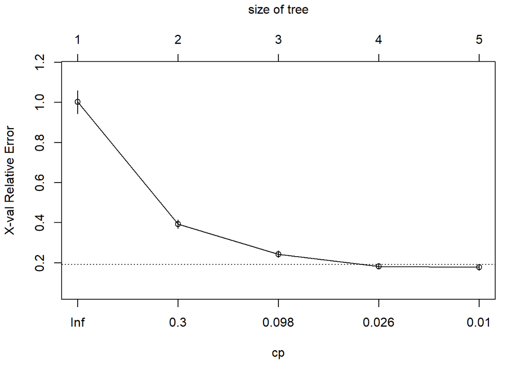

```r
plotcp(tree)
```

4. Predictions :

Let’s use this model to predict the values “charges” from the test set :

```r
predicted_tree=predict(tree,data.frame(test))
```

5. Submission File for tree :

```r
team1_DIA2_Tree = data.frame(id=rownames(test), charges=predicted_tree)
write.csv(team1_DIA2_Tree , file = "team1_DIA2_Tree.csv", row.names = F)
```

2. Multiple Linear Regression :
1. Fit of the Multiple Linear Regression Model :

```r
train_MLR=lm(charges~.,data=train)
train_MLR
```

```
##
## Call:
## lm(formula = charges ~ ., data = train)
##
## Coefficients:
## (Intercept)          age          sex          bmi     children       smoker
##   -11694.11       257.06        18.79       335.78       425.09     23647.82
##      region
##     -271.28
```

2. Predictions :

Let’s use this model to predict the values “charges” from the test set :

```r
predicted_MLR=predict(train_MLR,data.frame(test))
```

3. Submission File for tree :

```r
team1_DIA2_MLR = data.frame(id=rownames(test), charges=predicted_MLR)
write.csv(team1_DIA2_MLR , file = "team1_DIA2_MLR.csv", row.names = F)
```

3. Bagging :
1. Fit of the bagging Model :

```r
train_bagging=randomForest(x=train[1:6],y=train$charges,mtry=6)
train_bagging
```

```
##
## Call:
##  randomForest(x = train[1:6], y = train$charges, mtry = 6)
##                Type of random forest: regression
##                      Number of trees: 500
## No. of variables tried at each split: 6
##
##           Mean of squared residuals: 23598584
##                     % Var explained: 83.65
```

2. Predictions :

Let’s use this model to predict the values “charges” from the test set :

```r
predicted_bagging=predict(train_bagging,data.frame(test))
```

3. Submission File for tree :

```r
team1_DIA2_Bagging = data.frame(id=rownames(test), charges=predicted_bagging)
write.csv(team1_DIA2_Bagging , file = "team1_DIA2_Bagging.csv", row.names = F)
```

4. Random Forest :
1. Fit of the Random Forest :

```r
train_RF=randomForest(x=train[1:6],y=train$charges,mtry=6/3)
train_RF
```

```
##
## Call:
##  randomForest(x = train[1:6], y = train$charges, mtry = 6/3)
##                Type of random forest: regression
##                      Number of trees: 500
## No. of variables tried at each split: 2
##
##           Mean of squared residuals: 23079984
##                     % Var explained: 84.01
```

2. Predictions :

Let’s use this model to predict the values “charges” from the test set :

```r
predicted_RF=predict(train_RF,data.frame(test))
```

3. Importance of Variables in the Random Forest :

```r
importance(train_RF)
```

```
##          IncNodePurity
## age        20040528668
## sex         1393584668
## bmi        21334820296
## children    3531092847
## smoker     92146948666
## region      2900241968
```

Let’s plot them :

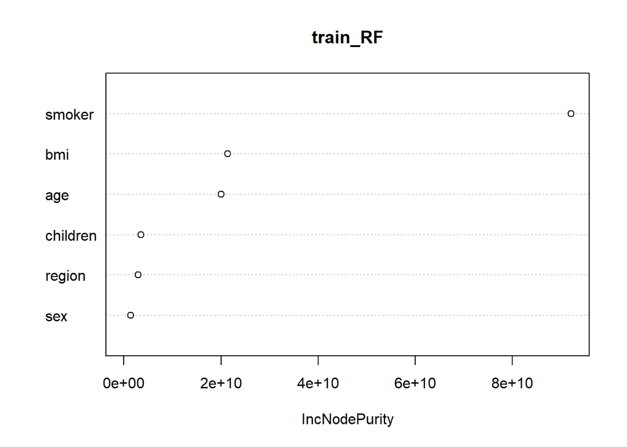

```r
varImpPlot(train_RF)
```

4. Submission File for tree :

```r
team1_DIA2_RF = data.frame(id=rownames(test), charges=predicted_RF)
write.csv(team1_DIA2_RF , file = "team1_DIA2_RF.csv", row.names = F)
```

5. Boosted Random Forest :
1. Fit of the Boosted Model :

```r
train_boost=gbm(charges~.,data=train,distribution="gaussian",n.trees=850,interaction.depth=3,shrinkage=0.01)
train_boost
```

```
## gbm(formula = charges ~ ., distribution = "gaussian", data = train,
##     n.trees = 850, interaction.depth = 3, shrinkage = 0.01)
## A gradient boosted model with gaussian loss function.
## 850 iterations were performed.
## There were 6 predictors of which 6 had non-zero influence.
```

2. Predictions :

Let’s use this model to predict the values “charges” from the test set :

```r
predicted_boosted=predict(train_boost,data.frame(test))
```

```
## Using 850 trees...
```

3. Submission File for tree :

```r
team1_DIA2_boosted = data.frame(id=rownames(test), charges=predicted_boosted)
write.csv(team1_DIA2_boosted , file = "team1_DIA2_boosted.csv", row.names = F)
```

```r
control = trainControl(method ="cv", number = 5)
train_ridge = train(x = train[1:6],y = train$charges,method = "glmnet",trControl = control)
train_ridge
```

```
## glmnet
##
## 1070 samples
##    6 predictor
##
## No pre-processing
## Resampling: Cross-Validated (5 fold)
## Summary of sample sizes: 856, 857, 857, 856, 854
## Resampling results across tuning parameters:
##
##   alpha  lambda      RMSE      Rsquared   MAE
##   0.10     18.74317  6165.574  0.7425311  4247.956
##   0.10    187.43175  6165.745  0.7426206  4257.873
##   0.10   1874.31749  6338.192  0.7427988  4524.000
##   0.55     18.74317  6164.548  0.7426389  4241.003
##   0.55    187.43175  6164.993  0.7429322  4243.488
##   0.55   1874.31749  6564.409  0.7355854  4714.746
##   1.00     18.74317  6164.383  0.7426667  4238.457
##   1.00    187.43175  6169.386  0.7428452  4236.642
##   1.00   1874.31749  6945.362  0.7122686  5043.580
##
## RMSE was used to select the optimal model using the smallest value.
## The final values used for the model were alpha = 1 and lambda = 18.74317.
```

2. Predictions :

Let’s use this model to predict the values “charges” from the test set :

```r
predicted_ridge=predict(train_ridge,data.frame(test))
```

3. Getting the mean validation score :

```r
mean(train_ridge$resample$RMSE)
```

```
## [1] 6164.383
```

4. Let’s plot it :

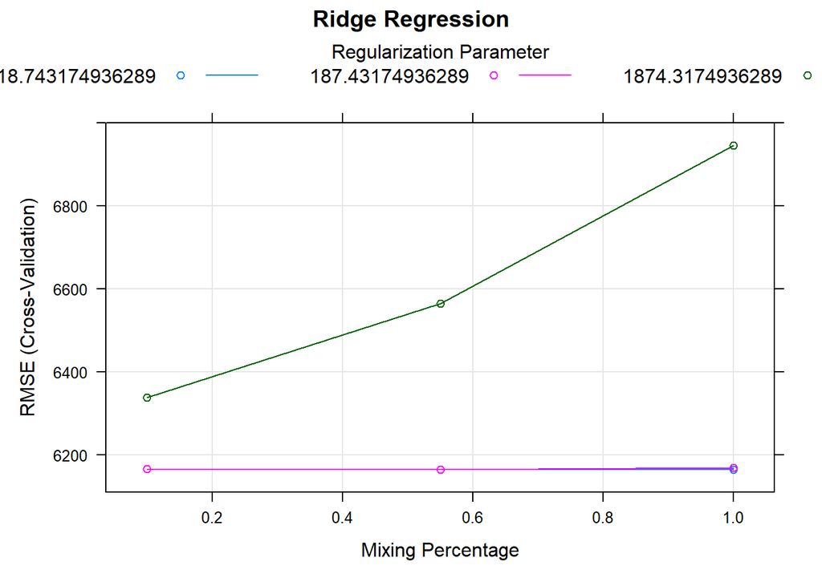

```r
plot(train_ridge, main="Ridge Regression")
```

5. Submission File for tree :

```r
team1_DIA2_ridge = data.frame(id=rownames(test), charges=predicted_ridge)
write.csv(team1_DIA2_ridge , file = "team1_DIA2_ridge.csv", row.names = F)
```

7. Stacking :

In order to not get different results, let’s add the seed function :

```r
set.seed(100)
```

1. Let’s add the algorithms we want to have :

```r
algorithms_to_use=c('rpart', 'glm', 'glmnet', 'svmRadial','gbm')
```

2. Fit of the stacking model and get the predictions :

```r
control_stacking=trainControl(method="repeatedcv", number=5, repeats=2, savePredictions=TRUE, classProbs=TRUE)

train_stack=caretList(charges~., data=train, trControl=control_stacking, methodList=algorithms_to_use)
predicted_stack = predict(train_stack, data.frame(test))
```

3. Submission File for Stack :

```r
team1_DIA2_stack = data.frame(id=rownames(test), charges=predicted_stack)
write.csv(team1_DIA2_stack , file = "team1_DIA2_stack.csv", row.names = F)
```

Final Submission :

```r
team1_DIA2_Final_Model = data.frame(id=rownames(test), charges=predicted_boosted)
write.csv(team1_DIA2_Final_Model , file = "team1_DIA2_Final_Model.csv", row.names = F)
```